[figure not shown]

# PEC0

## Multilayer Perceptron Training with different neural architectures and 2 learning rates (LR)

**Subject:** Deep Learning

**Master's Degree:** Master in Artificial Intelligence Research

**Academic Year:** 2025/2026

**Student:** Fernando Domingo Martínez Marco

**Email:** fmartinez24@alumno.uned.es

**Submission Date:** 10/12/2025

# Explanatory Memoir

## 1. Introduction and Objectives

The purpose of this experiment is to analyze in depth the influence of the learning rate (*Learning Rate*) and the architecture of a dense neural network on the model's performance during the classification task of the **MNIST** dataset, which contains handwritten digit images of 28×28 pixels. The main objective is to surpass the 98% accuracy threshold, applying both manual and automatic hyperparameter tuning strategies.

This memoir describes the entire process, from the definition of the base model to the automatic search for optimal configurations with **Keras Tuner**. The document covers the exploration phases of the *Learning Rate* using **LRFinder**, the comparison of derived architectures, the use of advanced *callbacks* for convergence control and regularization, and the final evaluation of the best model through predictions on the test set.

The experiment has been implemented using **TensorFlow and Keras** as the main framework, with an environment configured to ensure reproducibility by establishing fixed seeds (`SEED = 42`). Performance has been optimized by configuring the **GPU** when available, allowing strictly efficient training of the models.

The MNIST dataset has been divided into three subsets: 55,000 images for training, 5,000 for validation, and 10,000 for testing. All images have been normalized to the [0,1] range by dividing pixel values by 255.0, ensuring consistent processing for all evaluated models.

## 2. Base Architecture and Training Configuration

The base model was designed as a **Multilayer Perceptron (MLP)** using the Keras Sequential API. For the manual optimization phase, multiple architectures were evaluated, all of them dense (fully connected) neural networks with **ReLU** activation in the hidden layers and an output layer with **softmax** activation for the multi-class classification of the 10 MNIST digits.

The explored architectures varied in the number of hidden layers (3 and 4) and in the number of neurons per layer, following two main patterns:

- **Pattern A:** Higher number of neurons (e.g., 512, 256, 128).
- **Pattern B:** Lower number of neurons (e.g., 300, 200, 100).

To ensure controlled and reproducible training, the following *callbacks* were implemented: **EarlyStopping** (patience of 5 epochs) and **ModelCheckpoint** (save the best model).

## 3. Search for Optimal Learning Rate (Strategies A and B)

To identify an appropriate *Learning Rate*, the **LRFinder** technique, introduced by Leslie Smith (2017), was applied. This procedure involves training the model for a single epoch by progressively increasing the learning rate on a logarithmic scale. Based on the resulting curve, two strategies were defined:

**Strategy A (LR_A):** the optimal *Learning Rate* is taken as the value corresponding to **one-tenth of the point where the loss reaches its minimum**. This approach prioritizes stability.

**Strategy B (LR_B):** the optimal *Learning Rate* is selected as the value corresponding to **half of the point where the minimum loss is reached**. This method tends to favor faster convergence.

During execution, a logarithmic range between 1e-5 and 1 was explored. According to the visual interpretation of the curve, the approximate optimal values were:

- **LR_A ≈ 2.58×10⁻³**
- **LR_B ≈ 1.29×10⁻²**

These values were subsequently used to retrain the architectures defined in the next experimental phase.

## 4. Comparison of Derived Architectures and Selection of the Best Model

Eight different configurations were defined and trained, combining four architectures (3H_A, 3H_B, 4H_A, 4H_B) with the two learning rates. The following table summarizes the results, highlighting the model with the best performance.

[output not shown]

## 5. Automatic Hyperparameter Search with Keras Tuner

After completing the manual optimization, a second phase of automatic search was implemented using the **Keras Tuner** library. This approach aimed to empirically validate the previous results and systematically explore new combinations of architecture, optimizer, and learning rate.

A custom **TensorBoardTuner** class was developed to automatically register a **TensorBoard** *callback* for each *trial*, allowing for detailed subsequent inspection. The search space included the number of hidden layers, the number of neurons, the optimizer (Adam or SGD), and the learning rate.

## 7. Prediction with the Model and Preprocessing Optimization

### 7.1. Implementation of the Prediction System

Once the optimal model was obtained through the optimization process with Keras Tuner, a complete prediction system was developed to classify handwritten digits in external images. The system consists of three main components: image preprocessing, model inference, and results visualization.

The `preprocess_image()` function implements a transformation pipeline to adapt input images to the format required by MNIST. This process includes: grayscale conversion, color inversion, Otsu thresholding, bounding box cropping, and normalization.

### 7.2. Detected Problem: Failure in Prediction of Digit 9

During testing with the 10 validation images (digit0.png to digit9.png), a systematic failure in predicting digit 9 was identified, even though the model had an accuracy greater than 98% on the validation set. Analysis revealed that the error was not attributable to the trained model, but to the preprocessing stage.

Digit 9 has a characteristic morphology with a lower stroke (the "tail") that extends significantly. The initial padding of 20% was insufficient, causing the stroke to be cut off. As a consequence, the digit was confused with a 4 or a 7.

### 7.3. Implemented Solution

The padding factor in the preprocessing function was modified, increasing it from 0.2 to 0.3:

`padding = int(max(w, h) * 0.3) # Previously was 0.2`

This adjustment ensures that an additional margin is preserved around the digit during the bounding box cropping, ensuring that protruding elements are not eliminated.

### 7.4. Final Results

After padding optimization, the system achieved a **100% (10/10)** success rate on the test images. The model correctly classified all digits, including the problematic 9, with confidence levels above 95%. This case demonstrates the critical importance of preprocessing in deep learning systems.

# Code Block

The developed code block implements the entire experimental workflow described in the explanatory memoir. This code covers everything from initial environment setup to final evaluation, integrating both manual optimization based on LRFinder and automated hyperparameter search. The goal is to ensure reproducibility and surpass 98% accuracy in MNIST digit classification.

### 2. Data Loading, Normalization, and Preprocessing

The **MNIST** dataset is loaded directly from the Keras API. A critical preprocessing step is performed to normalize the images: pixel values (originally integers between 0 and 255) are divided by **255.0** to scale them to the floating-point range **[0, 1]**, which facilitates the convergence of the optimization algorithm. The dataset is explicitly partitioned into three subsets: **55,000 images** for effective training, **5,000 images** reserved for validation during tuning, and **10,000 images** for unbiased final testing. Additionally, the images are flattened from 28x28 matrices to 784-element vectors to feed the dense layers.

### 4. Exploration of the Learning Rate (LRFinder)

Before intensive training, the code implements the **LRFinder** logic. A base model is trained for one epoch by exponentially increasing the learning rate from 1e-5 to 1. Based on the resulting loss curve, two optimal rates are derived: **Strategy A (LR_A ≈ 2.58e-3)**, which seeks stability by selecting a low slope point (1/10 of the minimum), and **Strategy B (LR_B ≈ 1.29e-2)**, which prioritizes convergence speed (half of the minimum). These values are stored to parameterize subsequent trainings.

### 5. Training Cycle and Manual Evaluation

The core of the experiment consists of a loop that iterates over the eight possible combinations of architecture and Learning Rate. For each iteration, the model is instantiated and trained with a batch size of **32**. Advanced *callbacks* are implemented for training control: **EarlyStopping** with a patience of 5 epochs to stop the process if validation does not improve (avoiding overfitting), and **ModelCheckpoint** to save only the best weights obtained. After training, the model is evaluated on the test set, and key metrics such as *accuracy*, loss, and number of epochs to convergence are recorded for comparison.

### 6. Automatic Search with Keras Tuner

To validate the manual findings, **Keras Tuner** is integrated. A custom class `TensorBoardTuner` is defined to inject a TensorBoard callback into each trial, allowing detailed visualization of each test. The `build_model` function defines a dynamic search hyperspace including the number of layers, neurons per layer (decreasing), optimizer type (Adam vs SGD), and learning rate. The tuner executes a random search (*RandomSearch*) exploring multiple configurations to empirically find the optimal hyperparameter combination.

### 7. Predictions, Metrics, and Final Evaluation

```python
# ==========================================
# Configuración de entorno limpia y reproducible
# ==========================================

import os
import warnings

# ============================================================================
# SILENCIAR TODOS LOS WARNINGS DE TENSORFLOW (debe ir ANTES de importar TF)
# ============================================================================


# Nivel de logging de TensorFlow
os.environ['TF_CPP_MIN_LOG_LEVEL'] = '3'

# Deshabilitar mensajes de XLA (múltiples métodos)
os.environ['TF_XLA_FLAGS'] = '--tf_xla_enable_xla_devices'
os.environ['XLA_FLAGS'] = '--xla_gpu_cuda_data_dir=/path/to/nowhere'
# Silenciar logging del device compiler (XLA)
#os.environ["XLA_FLAGS"] = "--xla_cpu_enable_fast_math=false --xla_gpu_enable_fast_math=false --xla_hlo_profile=false"

# Silenciar ABSEIL/absl logging
os.environ["ABSL_MIN_LOG_LEVEL"] = "3"

# Deshabilitar oneDNN custom operations
#os.environ['TF_ENABLE_ONEDNN_OPTS'] = '0'

# Silenciar mensajes de CUDA y drivers
os.environ["CUDA_DEVICE_ORDER"] = "PCI_BUS_ID"
os.environ["NVIDIA_TF32_OVERRIDE"] = "0"

# Silenciar warnings de Python
warnings.filterwarnings('ignore')

import random
import numpy as np
import pandas as pd
from datetime import datetime
import matplotlib.pyplot as plt
import seaborn as sns
import tensorflow as tf
from tensorflow import keras
from tensorflow.keras.callbacks import EarlyStopping, ModelCheckpoint
from tensorflow.keras.utils import plot_model
from IPython.display import Image, display
import keras_tuner as kt
from keras import layers
from keras import callbacks
from PIL import Image, ImageOps
import math
import cv2

# Fijar semillas (reproducibilidad)
SEED = 42
os.environ['PYTHONHASHSEED'] = str(SEED)
random.seed(SEED)
np.random.seed(SEED)
```

```python
# Limpiar sesión anterior
tf.keras.backend.clear_session()

# Configurar GPU
gpus = tf.config.list_physical_devices('GPU')
if gpus:
    try:
        for gpu in gpus:
            tf.config.experimental.set_memory_growth(gpu, True)
    except RuntimeError:
        pass
    print("GPU activa: Sí")
else:
    print("GPU activa: No")

print("Entorno limpio listo.")
```

```
GPU activa: Sí
Entorno limpio listo.
```

```python
# 2.1. Configuración de la tipografía

plt.rcParams.update({
    'font.size': 11,
    'font.family': 'DejaVu Sans',
    'axes.titlesize': 13,
    'axes.labelsize': 12,
    'legend.fontsize': 11,
    'xtick.labelsize': 10,
    'ytick.labelsize': 10,
    'figure.figsize': (8, 5)
})
```

```python
# 2.2. Carga y preprocesamiento de MNIST
(X_train_full, y_train_full), (X_test, y_test) = keras.datasets.mnist.load_data()

# Normalizar píxeles a [0, 1]
X_train_full = X_train_full.astype(np.float32) / 255.0
X_test = X_test.astype(np.float32) / 255.0

# Crear conjunto de validación
X_valid, X_train = X_train_full[:5000], X_train_full[5000:]
y_valid, y_train = y_train_full[:5000], y_train_full[5000:]
print(f"Conjunto de entrenamiento: {X_train.shape}")
print(f"Conjunto de validación: {X_valid.shape}")
print(f"Conjunto de prueba: {X_test.shape}")
```

```
Conjunto de entrenamiento: (55000, 28, 28)
Conjunto de validación: (5000, 28, 28)
Conjunto de prueba: (10000, 28, 28)
```

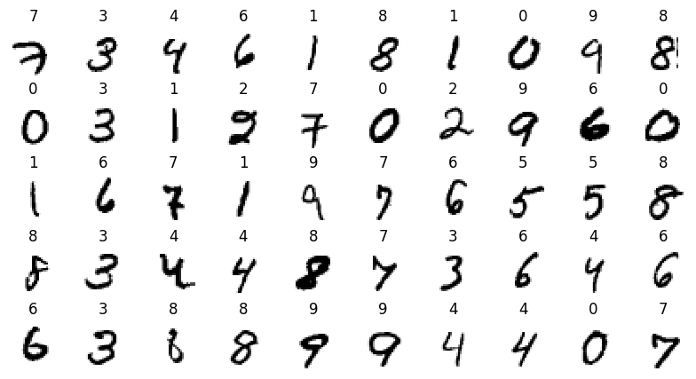

```python
# Mostrar un ejemplo de las imágenes del dataset

n_rows = 5
n_cols = 10
plt.figure(figsize=(n_cols, n_rows))
for row in range(n_rows):
    for col in range(n_cols):
        index = n_cols * row + col
        plt.subplot(n_rows, n_cols, index + 1)
        plt.imshow(X_train[index], cmap="binary", interpolation="nearest")
        plt.axis('off')
        plt.title(y_train[index], fontsize=12)
plt.subplots_adjust(wspace=0.2, hspace=0.5)
plt.show()
```

```
Ejecutando búsqueda de Learning Rate óptimo...
[LRFinder] total_iterations = 1719
1719/1719 ━━━━━━━━━━━━━━━━━━━━ 4s 2ms/step - accuracy: 0.5914 - loss: 1.2665
✓ Búsqueda completada
```

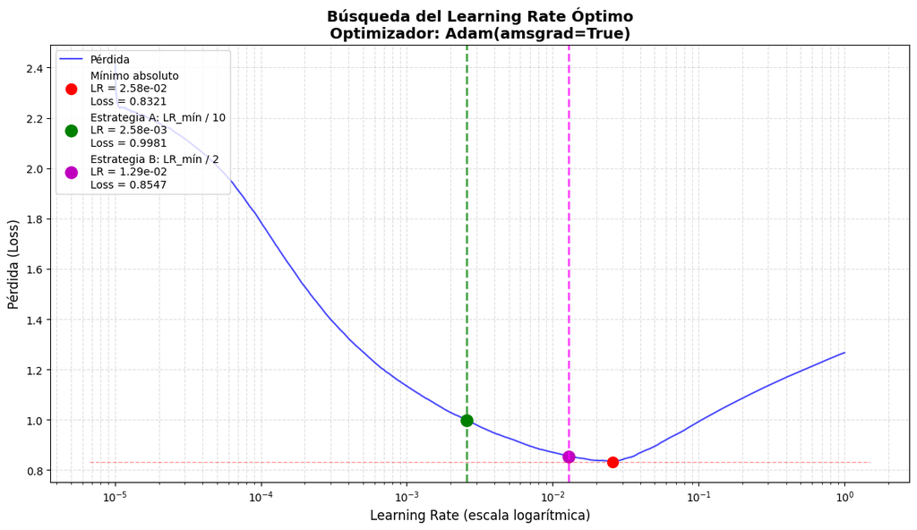

```
============================================================
RESULTADOS DE LA BÚSQUEDA DEL LEARNING RATE
============================================================

Mínimo de pérdida encontrado:
  Learning Rate: 2.58e-02
  Loss: 0.8321

Learning Rates recomendados:
  Estrategia A : 2.58e-03
  Estrategia B :     1.29e-02

============================================================

✓ Variables best_lr_A y best_lr_B creadas correctamente
```

```python
# ============================================================================
# BÚSQUEDA DEL LEARNING RATE ÓPTIMO
# ============================================================================

K = keras.backend

# ============================================================================
# 1. MODELO BASE
# ============================================================================
model_lr = keras.Sequential([
    keras.layers.Flatten(input_shape=[28, 28]),
    keras.layers.Dense(300, activation="relu"),
    keras.layers.Dense(100, activation="relu"),
    keras.layers.Dense(10, activation="softmax")
])

optimizer = keras.optimizers.Adam(learning_rate=1e-3, amsgrad=True)
model_lr.compile(loss="sparse_categorical_crossentropy", optimizer=optimizer, metrics=["accuracy"])

# ============================================================================
# 2. CALLBACK: LRFinder
# ============================================================================

batch_size = 32
steps_per_epoch = math.ceil(len(X_train) / batch_size)

class LRFinder(keras.callbacks.Callback):
    def __init__(self, min_lr=1e-5, max_lr=1, steps_per_epoch=steps_per_epoch, epochs=1, verbose=0):
        super().__init__()
        self.min_lr = float(min_lr)
        self.max_lr = float(max_lr)
        self.epochs = int(epochs)
        self.verbose = verbose
        self._steps_per_epoch = steps_per_epoch
        self.iteration = 0
        self.total_iterations = None
        self.history = {"lr": [], "loss": []}

    def on_train_begin(self, logs=None):
        # Intentar inferir steps_per_epoch si no se pasa explícitamente
        if self._steps_per_epoch is None:
            if hasattr(self.params, "get") and self.params.get("steps"):
                self._steps_per_epoch = int(self.params.get("steps"))
            elif "samples" in self.params and "batch_size" in self.params:
                self._steps_per_epoch = max(1, math.ceil(self.params["samples"] / self.params["batch_size"]))
            else:
                self._steps_per_epoch = 1
        self.total_iterations = max(1, int(self._steps_per_epoch * max(1, self.epochs)))
        if self.verbose:
            print(f"[LRFinder] total_iterations = {self.total_iterations}")

    def on_batch_end(self, batch, logs=None):
        logs = logs or {}
        self.iteration += 1

        pct = min(max(self.iteration / float(self.total_iterations), 1e-12), 1.0)
        lr = self.min_lr * (self.max_lr / self.min_lr) ** pct

        # Asignar LR de forma compatible con TF/Keras
        try:
            K.set_value(self.model.optimizer.learning_rate, lr)
        except Exception:
            try:
                self.model.optimizer.learning_rate.assign(lr)
            except Exception:
                try:
                    K.set_value(self.model.optimizer.lr, lr)
                except Exception:
                    if self.verbose:
                        print("[LRFinder] WARNING: no pude asignar el learning rate al optimizador.")

        loss = logs.get("loss")
        self.history["lr"].append(lr)
        self.history["loss"].append(float(loss) if loss is not None else np.inf)

        if self.iteration >= self.total_iterations:
            self.model.stop_training = True



# ============================================================================
# 4. EJECUCIÓN DE LA BÚSQUEDA
# ============================================================================
print("Ejecutando búsqueda de Learning Rate óptimo...")
lr_finder = LRFinder(min_lr=1e-5, max_lr=1, steps_per_epoch=steps_per_epoch, epochs=1, verbose=1)
model_lr.fit(X_train, y_train, epochs=1, batch_size=batch_size, callbacks=[lr_finder], verbose=1)
print("✓ Búsqueda completada")

# ============================================================================
# 5. ANÁLISIS DE RESULTADOS
# ============================================================================
losses = np.array(lr_finder.history["loss"])
lrs = np.array(lr_finder.history["lr"])

min_loss_idx = np.argmin(losses)
min_loss = losses[min_loss_idx]
lr_at_min_loss = lrs[min_loss_idx]

# Estrategias de selección
best_lr_A = lr_at_min_loss / 10  # libro
best_lr_B = lr_at_min_loss / 2   # código en github

# Validaciones de rango
if best_lr_A < lrs[0]:
    best_lr_A = lrs[0]
    print(f"  Advertencia: best_lr_A ajustado al mínimo explorado: {best_lr_A:.2e}")
if best_lr_B > lrs[-1]:
    best_lr_B = lrs[-1]
    print(f"  Advertencia: best_lr_B ajustado al máximo explorado: {best_lr_B:.2e}")

# ============================================================================
# 6. GRÁFICO
# ============================================================================
x_min, x_max = min(lrs) / 1.5, max(lrs) * 1.5
y_min = 0
y_max = min(losses[0] * 1.2, min_loss * 3)
y_max = min(y_max, np.percentile(losses, 90) * 1.2)

plt.figure(figsize=(12, 7))
plt.plot(lrs, losses, 'b-', linewidth=1.5, label="Pérdida", alpha=0.7)

plt.plot(lr_at_min_loss, min_loss, 'ro', markersize=10,
         label=f"Mínimo absoluto\nLR = {lr_at_min_loss:.2e}\nLoss = {min_loss:.4f}")

idx_A = (np.abs(lrs - best_lr_A)).argmin()
plt.plot(best_lr_A, losses[idx_A], 'go', markersize=11,
         label=f"Estrategia A: LR_mín / 10\nLR = {best_lr_A:.2e}\nLoss = {losses[idx_A]:.4f}")
plt.axvline(best_lr_A, color='green', linestyle='--', alpha=0.7, linewidth=2)

idx_B = (np.abs(lrs - best_lr_B)).argmin()
plt.plot(best_lr_B, losses[idx_B], 'mo', markersize=11,
         label=f"Estrategia B: LR_mín / 2\nLR = {best_lr_B:.2e}\nLoss = {losses[idx_B]:.4f}")
plt.axvline(best_lr_B, color='magenta', linestyle='--', alpha=0.7, linewidth=2)

plt.hlines(min_loss, x_min, x_max, colors='red', linestyles='dashed', alpha=0.4, linewidth=1)
plt.xscale('log')
plt.xlabel("Learning Rate (escala logarítmica)", fontsize=12)
plt.ylabel("Pérdida (Loss)", fontsize=12)
plt.title("Búsqueda del Learning Rate Óptimo\nOptimizador: Adam(amsgrad=True)", fontsize=14, fontweight='bold')
plt.grid(True, which="both", ls="--", alpha=0.4)
plt.legend(loc='upper left', fontsize=10)
plt.tight_layout()
plt.show()

# ============================================================================
# 7. RESUMEN
# ============================================================================
print(f"\n{'='*60}")
print("RESULTADOS DE LA BÚSQUEDA DEL LEARNING RATE")
print(f"{'='*60}")
print(f"\nMínimo de pérdida encontrado:")
print(f"  Learning Rate: {lr_at_min_loss:.2e}")
print(f"  Loss: {min_loss:.4f}")
print(f"\nLearning Rates recomendados:")
print(f"  Estrategia A : {best_lr_A:.2e}")
print(f"  Estrategia B :     {best_lr_B:.2e}")
print(f"\n{'='*60}\n")
print("✓ Variables best_lr_A y best_lr_B creadas correctamente")
```

```python
# ============================================================================
# 2.4. Definición de las arquitecturas a comparar
# ============================================================================

# Arquitecturas con 3 capas ocultas
def create_model_3h_a():
    """Modelo con 3 capas ocultas: [512, 256, 128]"""
    return keras.models.Sequential([
        keras.layers.Flatten(input_shape=[28, 28]),
        keras.layers.Dense(512, activation="relu"),
        keras.layers.Dense(256, activation="relu"),
        keras.layers.Dense(128, activation="relu"),
        keras.layers.Dense(10, activation="softmax")
    ])

def create_model_3h_b():
    """Modelo con 3 capas ocultas: [300, 200, 100]"""
    return keras.models.Sequential([
        keras.layers.Flatten(input_shape=[28, 28]),
        keras.layers.Dense(300, activation="relu"),
        keras.layers.Dense(200, activation="relu"),
        keras.layers.Dense(100, activation="relu"),
        keras.layers.Dense(10, activation="softmax")
    ])

# Arquitecturas con 4 capas ocultas
def create_model_4h_a():
    """Modelo con 4 capas ocultas: [512, 256, 128, 64]"""
    return keras.models.Sequential([
        keras.layers.Flatten(input_shape=[28, 28]),
        keras.layers.Dense(512, activation="relu"),
        keras.layers.Dense(256, activation="relu"),
        keras.layers.Dense(128, activation="relu"),
        keras.layers.Dense(64, activation="relu"),
        keras.layers.Dense(10, activation="softmax")
    ])

def create_model_4h_b():
    """Modelo con 4 capas ocultas: [300, 200, 100, 50]"""
    return keras.models.Sequential([
        keras.layers.Flatten(input_shape=[28, 28]),
        keras.layers.Dense(300, activation="relu"),
        keras.layers.Dense(200, activation="relu"),
        keras.layers.Dense(100, activation="relu"),
        keras.layers.Dense(50, activation="relu"),
        keras.layers.Dense(10, activation="softmax")
    ])

# Lista de modelos para la primera ronda de comparación
models_to_test = [
    ("3H_A", create_model_3h_a),
    ("3H_B", create_model_3h_b),
    ("4H_A", create_model_4h_a),
    ("4H_B", create_model_4h_b)
]

# ============================================================================
# Callbacks
# ============================================================================

def get_callbacks(model_name):
    """Crea callbacks para TensorBoard, checkpoints y early stopping"""
    base_log_dir = "logs_2"
    os.makedirs(base_log_dir, exist_ok=True)

    timestamp = datetime.now().strftime("%Y%m%d-%H%M%S")
    log_dir = os.path.join(base_log_dir, f"{model_name}_{timestamp}")

    tensorboard_cb = keras.callbacks.TensorBoard(log_dir=log_dir, histogram_freq=1)

    checkpoint_cb = keras.callbacks.ModelCheckpoint(
        filepath=f"{model_name}_best.keras",
        save_best_only=True,
        monitor='val_loss',
        verbose=1
    )

    earlystop_cb = keras.callbacks.EarlyStopping(
        patience=5,
        restore_best_weights=True,
        monitor='val_loss',
        min_delta=0.001,
        verbose=1
    )

    return [tensorboard_cb, checkpoint_cb, earlystop_cb]

# ============================================================================
# Diccionarios para almacenar resultados
# ============================================================================

histories = {}
results_phase_1 = {}

# ============================================================================
# Verificación de LR detectados
# ============================================================================

try:
    print(f"Learning Rates detectados:")
    print(f"  Estrategia A (1/10 del LR mínimo): {best_lr_A:.2e}")
    print(f"  Estrategia B (1/2 del LR mínimo): {best_lr_B:.2e}")
except NameError:
    raise NameError("ERROR: best_lr_A y best_lr_B no están definidos. "
                    "Ejecuta primero la celda del LRFinder.")

learning_rates_to_test = [
    ("LR_A", best_lr_A),
    ("LR_B", best_lr_B)
]

# ============================================================================
# ENTRENAMIENTO DE MODELOS
# ============================================================================

print(f"\n{'='*60}")
print(f"INICIO DEL EXPERIMENTO")
print(f"{'='*60}\n")

for lr_name, lr_value in learning_rates_to_test:
    print(f"\n{'='*60}")
    print(f"ENTRENANDO CON {lr_name}: LR = {lr_value:.2e}")
    print(f"{'='*60}\n")

    for name, model_fn in models_to_test:
        full_name = f"{name}_{lr_name}"
        print(f"\n--- Entrenando modelo {full_name} ---")

        model = model_fn()

        model.compile(
            loss="sparse_categorical_crossentropy",
            optimizer=keras.optimizers.SGD(learning_rate=lr_value, momentum=0.9, nesterov=True),
            metrics=["accuracy"]
        )

        history = model.fit(
            X_train, y_train,
            epochs=100,
            validation_data=(X_valid, y_valid),
            callbacks=get_callbacks(full_name),
            verbose=1
        )

        histories[full_name] = history

        test_loss, test_acc = model.evaluate(X_test, y_test, verbose=0)
        results_phase_1[full_name] = {
            'test_accuracy': test_acc,
            'test_loss': test_loss,
            'best_val_accuracy': max(history.history['val_accuracy']),
            'best_val_loss': min(history.history['val_loss']),
            'final_epoch': len(history.history['loss'])
        }

        print(f"Precisión en test: {test_acc * 100:.2f}%")
        print(f"Mejor val_accuracy: {max(history.history['val_accuracy']) * 100:.2f}%")

        #model.save(f"{full_name}_final.keras")

# ============================================================================
# TABLA COMPARATIVA DE RESULTADOS
# ============================================================================

print(f"\n{'='*60}")
print("TABLA COMPARATIVA DE RESULTADOS")
print(f"{'='*60}\n")

df_results = pd.DataFrame(results_phase_1).T
df_results = df_results.sort_values('best_val_accuracy', ascending=False)
df_results['test_accuracy'] = df_results['test_accuracy'] * 100
df_results['best_val_accuracy'] = df_results['best_val_accuracy'] * 100

display(df_results.style.set_caption("Comparativa de modelos").format({
    "test_accuracy": "{:.2f}",
    "best_val_accuracy": "{:.2f}",
    "test_loss": "{:.4f}",
    "best_val_loss": "{:.4f}"
}))

# ============================================================================
# RESUMEN FINAL
# ============================================================================

sorted_results = sorted(results_phase_1.items(), key=lambda x: x[1]['best_val_accuracy'], reverse=True)
best_model_name, best_metrics = sorted_results[0]

print(f"\n{'='*60}")
print("RESUMEN FINAL")
print(f"{'='*60}")
print(f"\nMEJOR MODELO: {best_model_name}")
print(f"  Test Accuracy: {best_metrics['test_accuracy']*100:.2f}%")
print(f"  Val Accuracy: {best_metrics['best_val_accuracy']*100:.2f}%")
print(f"  Épocas completadas: {best_metrics['final_epoch']}")
print(f"\n{'='*60}\n")
```

```
Learning Rates detectados:
  Estrategia A (1/10 del LR mínimo): 2.58e-03
  Estrategia B (1/2 del LR mínimo): 1.29e-02

============================================================
INICIO DEL EXPERIMENTO
============================================================


============================================================
ENTRENANDO CON LR_A: LR = 2.58e-03
============================================================


--- Entrenando modelo 3H_A_LR_A ---
1719/1719 ━━━━━━━━━━━━━━━━━━━━ 0s 2ms/step - accuracy: 0.8028 - loss: 0.7134
Epoch 1: val_loss improved from None to 0.18908, saving model to 3H_A_LR_A_best.keras
1719/1719 ━━━━━━━━━━━━━━━━━━━━ 9s 3ms/step - accuracy: 0.8904 - loss: 0.3946 - val_accuracy: 0.9456 - val_loss: 0.1891
1689/1719 ━━━━━━━━━━━━━━━━━━━━ 0s 1ms/step - accuracy: 0.9481 - loss: 0.1807
Epoch 2: val_loss improved from 0.18908 to 0.14239, saving model to 3H_A_LR_A_best.keras
1719/1719 ━━━━━━━━━━━━━━━━━━━━ 2s 1ms/step - accuracy: 0.9523 - loss: 0.1639 - val_accuracy: 0.9576 - val_loss: 0.1424
1701/1719 ━━━━━━━━━━━━━━━━━━━━ 0s 1ms/step - accuracy: 0.9646 - loss: 0.1229
Epoch 3: val_loss improved from 0.14239 to 0.10744, saving model to 3H_A_LR_A_best.keras
1719/1719 ━━━━━━━━━━━━━━━━━━━━ 2s 1ms/step - accuracy: 0.9667 - loss: 0.1144 - val_accuracy: 0.9702 - val_loss: 0.1074
1679/1719 ━━━━━━━━━━━━━━━━━━━━ 0s 1ms/step - accuracy: 0.9732 - loss: 0.0907
Epoch 4: val_loss improved from 0.10744 to 0.08769, saving model to 3H_A_LR_A_best.keras
1719/1719 ━━━━━━━━━━━━━━━━━━━━ 2s 1ms/step - accuracy: 0.9753 - loss: 0.0856 - val_accuracy: 0.9752 - val_loss: 0.0877
1708/1719 ━━━━━━━━━━━━━━━━━━━━ 0s 1ms/step - accuracy: 0.9793 - loss: 0.0680
Epoch 5: val_loss improved from 0.08769 to 0.08140, saving model to 3H_A_LR_A_best.keras
1719/1719 ━━━━━━━━━━━━━━━━━━━━ 2s 1ms/step - accuracy: 0.9802 - loss: 0.0667 - val_accuracy: 0.9754 - val_loss: 0.0814
1676/1719 ━━━━━━━━━━━━━━━━━━━━ 0s 1ms/step - accuracy: 0.9861 - loss: 0.0509
Epoch 6: val_loss improved from 0.08140 to 0.07179, saving model to 3H_A_LR_A_best.keras
1719/1719 ━━━━━━━━━━━━━━━━━━━━ 2s 1ms/step - accuracy: 0.9849 - loss: 0.0528 - val_accuracy: 0.9784 - val_loss: 0.0718
1707/1719 ━━━━━━━━━━━━━━━━━━━━ 0s 1ms/step - accuracy: 0.9873 - loss: 0.0440
Epoch 7: val_loss improved from 0.07179 to 0.06828, saving model to 3H_A_LR_A_best.keras
1719/1719 ━━━━━━━━━━━━━━━━━━━━ 2s 1ms/step - accuracy: 0.9879 - loss: 0.0422 - val_accuracy: 0.9786 - val_loss: 0.0683
1700/1719 ━━━━━━━━━━━━━━━━━━━━ 0s 1ms/step - accuracy: 0.9906 - loss: 0.0339
Epoch 8: val_loss improved from 0.06828 to 0.06568, saving model to 3H_A_LR_A_best.keras
1719/1719 ━━━━━━━━━━━━━━━━━━━━ 2s 1ms/step - accuracy: 0.9907 - loss: 0.0338 - val_accuracy: 0.9800 - val_loss: 0.0657
1708/1719 ━━━━━━━━━━━━━━━━━━━━ 0s 1ms/step - accuracy: 0.9936 - loss: 0.0247
```

[output cut: 318 more lines]

```
1719/1719 ━━━━━━━━━━━━━━━━━━━━ 2s 1ms/step - accuracy: 0.9939 - loss: 0.0194 - val_accuracy: 0.9778 - val_loss: 0.0872
1680/1719 ━━━━━━━━━━━━━━━━━━━━ 0s 1ms/step - accuracy: 0.9958 - loss: 0.0121
Epoch 10: val_loss did not improve from 0.07639
1719/1719 ━━━━━━━━━━━━━━━━━━━━ 2s 1ms/step - accuracy: 0.9949 - loss: 0.0155 - val_accuracy: 0.9766 - val_loss: 0.0910
1693/1719 ━━━━━━━━━━━━━━━━━━━━ 0s 1ms/step - accuracy: 0.9950 - loss: 0.0155
Epoch 11: val_loss did not improve from 0.07639
1719/1719 ━━━━━━━━━━━━━━━━━━━━ 2s 1ms/step - accuracy: 0.9949 - loss: 0.0154 - val_accuracy: 0.9782 - val_loss: 0.0953
Epoch 11: early stopping
Restoring model weights from the end of the best epoch: 6.
Precisión en test: 97.92%
Mejor val_accuracy: 98.02%

============================================================
TABLA COMPARATIVA DE RESULTADOS
============================================================
```

Comparativa de modelos

|  | test_accuracy | test_loss | best_val_accuracy | best_val_loss | final_epoch |
| --- | --- | --- | --- | --- | --- |
| 4H_A_LR_B | 98.21 | 0.0652 | 98.34 | 0.0645 | 11.000000 |
| 3H_B_LR_A | 97.98 | 0.0751 | 98.32 | 0.0646 | 20.000000 |
| 3H_A_LR_B | 97.81 | 0.0731 | 98.32 | 0.0655 | 10.000000 |
| 3H_A_LR_A | 97.94 | 0.0696 | 98.24 | 0.0619 | 15.000000 |
| 4H_B_LR_A | 97.80 | 0.0709 | 98.22 | 0.0720 | 14.000000 |
| 3H_B_LR_B | 97.85 | 0.0670 | 98.16 | 0.0670 | 9.000000 |
| 4H_A_LR_A | 97.75 | 0.0763 | 98.08 | 0.0720 | 11.000000 |
| 4H_B_LR_B | 97.92 | 0.0731 | 98.02 | 0.0764 | 11.000000 |

```
============================================================
RESUMEN FINAL
============================================================

MEJOR MODELO: 4H_A_LR_B
  Test Accuracy: 98.21%
  Val Accuracy: 98.34%
  Épocas completadas: 11

============================================================
```

```python
from IPython.display import Image, display

#Cargar el modelo
best_model = keras.models.load_model(f"{best_model_name}_best.keras")

# Nombre del modelo para mostrar
titulo_modelo = f"Mejor modelo: {best_model_name}"

# Ruta del PNG
png_file = "best_model.png"

# Generar el diagrama
plot_model(
    best_model,
    to_file=png_file,
    show_shapes=True,
    show_dtype=True,
    show_layer_names=True,
    rankdir="BT",
    expand_nested=True,
    dpi=600
)

# Mostrar título y PNG en Jupyter
print("\n" + "="*80)
print(titulo_modelo)
print("="*80)
display(Image(filename=png_file))
```

```
================================================================================
Mejor modelo: 4H_A_LR_B
================================================================================
```

[figure not shown]

```python
# Cargar la extensión de TensorBoard
%load_ext tensorboard

# Ejecutar TensorBoard dentro de Jupyter
%tensorboard --logdir logs_2
```

### TensorBoard *"Scalars"* Panel: evolution of metrics

[figure not shown]

Figure 1. Representation of *"accuracy"* vs epochs

[figure not shown]

Figure 2. Representation of *"loss"* vs epochs

```python
# =============================================================================
# 2.8. Búsqueda automática de hiperparámetros con Keras Tuner
# =============================================================================
# Este bloque demuestra cómo automatizar
# la selección de arquitectura y tasa de aprendizaje usando Keras Tuner,
# manteniendo el objetivo de >98% de precisión en MNIST.
# Soporte para TensorBoard con logs por trial

import keras_tuner as kt
from keras import layers
from keras import callbacks
import os


class TensorBoardTuner(kt.RandomSearch):
    def run_trial(self, trial, *args, **kwargs):
        """
        Sobrescribe run_trial para añadir un TensorBoard callback
        que registre logs por trial en una carpeta visible para TensorBoard.
        """
        # Carpeta común para todos los logs
        log_dir_root = os.path.join(self.directory, "tb_logs", self.project_name)
        trial_log_dir = os.path.join(log_dir_root, trial.trial_id)
        os.makedirs(trial_log_dir, exist_ok=True)

        tb_callback = callbacks.TensorBoard(
            log_dir=trial_log_dir,
            histogram_freq=1,
            write_graph=True,
            update_freq='epoch'
        )

        # Aseguramos que 'callbacks' exista en kwargs
        if 'callbacks' not in kwargs:
            kwargs['callbacks'] = []
        kwargs['callbacks'].append(tb_callback)

        # Llamamos al método original
        return super().run_trial(trial, *args, **kwargs)


def build_model(hp):
    '''
    Función de construcción de modelo para Keras Tuner.
    Busca:
      - Número de capas ocultas (3 o 4)
      - Neuronas por capa
      - Tasa de aprendizaje óptima
    '''
    model = keras.Sequential()
    model.add(layers.Flatten(input_shape=[28, 28]))

    # Número de capas ocultas: 3 o 4
    num_layers = hp.Choice('num_layers', values=[3, 4])

    # Neuronas por capa: decrecientes
    units = []
    for i in range(num_layers):
        # La primera capa tiene más neuronas; las siguientes van reduciéndose
        max_units = 512 if i == 0 else units[-1]
        units.append(hp.Int(f'units_layer_{i}', min_value=32, max_value=max_units, step=32))
        model.add(keras.layers.Dense(units=units[-1], activation='relu'))

    # Capa de salida
    model.add(layers.Dense(10, activation='softmax'))

    # Elegir el optimizador
    optimizer_choice = hp.Choice('optimizer', values=['adam', 'sgd'])

    if optimizer_choice == 'adam':
        lr = hp.Float('learning_rate_adam', min_value=1e-4, max_value=1e-2, sampling='log')
        optimizer = keras.optimizers.Adam(learning_rate=lr)
    elif optimizer_choice == 'sgd':
        lr = hp.Float('learning_rate_sgd', min_value=1e-3, max_value=1e-1, sampling='log')
        momentum = hp.Float('momentum_sgd', min_value=0.8, max_value=0.99, step=0.01)
        optimizer = keras.optimizers.SGD(learning_rate=lr, momentum=momentum)

    model.compile(
        optimizer=optimizer,
        loss='sparse_categorical_crossentropy',
        metrics=['accuracy']
    )
    return model


# Instancia del tuner (usamos la clase personalizada para TensorBoard)
tuner = TensorBoardTuner(
    build_model,
    objective='val_accuracy',
    max_trials=20,
    directory='my_tuner_dir',
    project_name='mnist_mlp_pec0'
)

# Realizamos la búsqueda (usamos un subconjunto si se desea acelerar, pero aquí usamos todo)
tuner.search(X_train, y_train, epochs=20, validation_data=(X_valid, y_valid), verbose=1)

# Mostrar resumen de resultados
print("\n" + "="*70)
print("RESUMEN DE LA BÚSQUEDA DE KERAS TUNER")
print("="*70)
tuner.results_summary()

# Obtenemos los mejores hiperparámetros
best_hps = tuner.get_best_hyperparameters(num_trials=1)[0]

print("\n" + "="*70)
print("MEJORES HIPERPARÁMETROS ENCONTRADOS")
print("="*70)
print(f"- Número de capas ocultas: {best_hps.get('num_layers')}")
for i in range(best_hps.get('num_layers')):
    print(f"- Neuronas en capa {i}: {best_hps.get(f'units_layer_{i}')}")

# Nota: el learning_rate depende del optimizador
if best_hps.get('optimizer') == 'adam':
    print(f"- Optimizador: Adam")
    print(f"- Learning rate: {best_hps.get('learning_rate_adam'):.2e}")
else:
    print(f"- Optimizador: SGD")
    print(f"- Learning rate: {best_hps.get('learning_rate_sgd'):.2e}")
    print(f"- Momentum: {best_hps.get('momentum_sgd'):.2f}")

# Obtener el mejor trial
best_trial = tuner.oracle.get_best_trials(num_trials=1)[0]
print(f"\n- Trial ID: {best_trial.trial_id}")
print(f"- Val Accuracy durante búsqueda: {best_trial.score:.4f} ({best_trial.score*100:.2f}%)")

# Construir el mejor modelo con los hiperparámetros óptimos
print("\n" + "="*70)
print("ENTRENAMIENTO DEL MEJOR MODELO")
print("="*70)

best_model_kt = tuner.hypermodel.build(best_hps)

# Mostrar arquitectura del mejor modelo
print("\nArquitectura del mejor modelo:")
best_model_kt.summary()

# Callbacks para el entrenamiento final
callbacks_tuner = [
    keras.callbacks.EarlyStopping(
        patience=10,
        restore_best_weights=True,
        monitor='val_accuracy'
    ),
    keras.callbacks.ModelCheckpoint(
        filepath="best_model_tuner.keras",
        save_best_only=True,
        monitor='val_accuracy'
    )
]

# Entrenar el mejor modelo con más épocas
print("\nEntrenando el mejor modelo con 100 épocas...")
history_tuner = best_model_kt.fit(
    X_train, y_train,
    epochs=100,
    validation_data=(X_valid, y_valid),
    callbacks=callbacks_tuner,
    verbose=1
)

# Evaluar en el conjunto de prueba
print("\n" + "="*70)
print("EVALUACIÓN FINAL EN CONJUNTO DE PRUEBA")
print("="*70)

test_loss_tuner, test_acc_tuner = best_model_kt.evaluate(X_test, y_test, verbose=0)
print(f"\nPrecisión en test: {test_acc_tuner * 100:.2f}%")
print(f"Pérdida en test: {test_loss_tuner:.4f}")
print("Objetivo (>98%) " + ("✓ CUMPLIDO" if test_acc_tuner > 0.98 else "✗ NO ALCANZADO"))

# Información adicional sobre el entrenamiento
best_val_acc = max(history_tuner.history['val_accuracy'])
best_epoch = history_tuner.history['val_accuracy'].index(best_val_acc) + 1
print(f"\nMejor val_accuracy durante entrenamiento: {best_val_acc:.4f} ({best_val_acc*100:.2f}%)")
print(f"Alcanzado en época: {best_epoch}")
print(f"Épocas totales entrenadas: {len(history_tuner.history['val_accuracy'])}")

# Guardar información del mejor modelo
print("\n" + "="*70)
print("ARCHIVOS GENERADOS")
print("="*70)
print(f"- Modelo guardado: best_model_tuner.keras")
print(f"- Logs de TensorBoard: my_tuner_dir/tb_logs/mnist_mlp_pec0/{best_trial.trial_id}")
print(f"- Pesos del trial: my_tuner_dir/mnist_mlp_pec0/trial_{best_trial.trial_id}/checkpoint.weights.h5")

print("\nPara visualizar en TensorBoard:")
print(f"tensorboard --logdir=my_tuner_dir/tb_logs/mnist_mlp_pec0")
```

```
Trial 20 Complete [00h 00m 58s]
val_accuracy: 0.9843999743461609

Best val_accuracy So Far: 0.9843999743461609
Total elapsed time: 00h 18m 52s

======================================================================
RESUMEN DE LA BÚSQUEDA DE KERAS TUNER
======================================================================
Results summary
Results in my_tuner_dir/mnist_mlp_pec0
Showing 10 best trials
Objective(name="val_accuracy", direction="max")

Trial 19 summary
Hyperparameters:
num_layers: 4
units_layer_0: 448
units_layer_1: 32
units_layer_2: 32
optimizer: sgd
learning_rate_adam: 0.0019249832506576486
units_layer_3: 32
learning_rate_sgd: 0.0027827185198563307
momentum_sgd: 0.9700000000000001
Score: 0.9843999743461609

Trial 11 summary
Hyperparameters:
num_layers: 3
units_layer_0: 512
units_layer_1: 32
units_layer_2: 32
optimizer: adam
learning_rate_adam: 0.0003197491003350276
units_layer_3: 32
learning_rate_sgd: 0.06182534979970842
momentum_sgd: 0.8
Score: 0.984000027179718

```

[output cut: 107 more lines]

```
- Neuronas en capa 1: 32
- Neuronas en capa 2: 32
- Neuronas en capa 3: 32
- Optimizador: SGD
- Learning rate: 2.78e-03
- Momentum: 0.97

- Trial ID: 19
- Val Accuracy durante búsqueda: 0.9844 (98.44%)

======================================================================
ENTRENAMIENTO DEL MEJOR MODELO
======================================================================

Arquitectura del mejor modelo:
```

```
Model: "sequential_1"
```

```
┏━━━━━━━━━━━━━━━━━━━━━━━━━━━━━━━━━┳━━━━━━━━━━━━━━━━━━━━━━━━┳━━━━━━━━━━━━━━━┓
┃ Layer (type)                    ┃ Output Shape           ┃       Param # ┃
┡━━━━━━━━━━━━━━━━━━━━━━━━━━━━━━━━━╇━━━━━━━━━━━━━━━━━━━━━━━━╇━━━━━━━━━━━━━━━┩
│ flatten_1 (Flatten)             │ (None, 784)            │             0 │
├─────────────────────────────────┼────────────────────────┼───────────────┤
│ dense_5 (Dense)                 │ (None, 448)            │       351,680 │
├─────────────────────────────────┼────────────────────────┼───────────────┤
│ dense_6 (Dense)                 │ (None, 32)             │        14,368 │
├─────────────────────────────────┼────────────────────────┼───────────────┤
│ dense_7 (Dense)                 │ (None, 32)             │         1,056 │
├─────────────────────────────────┼────────────────────────┼───────────────┤
│ dense_8 (Dense)                 │ (None, 32)             │         1,056 │
├─────────────────────────────────┼────────────────────────┼───────────────┤
│ dense_9 (Dense)                 │ (None, 10)             │           330 │
└─────────────────────────────────┴────────────────────────┴───────────────┘
```

```
 Total params: 368,490 (1.41 MB)
```

```
 Trainable params: 368,490 (1.41 MB)
```

```
 Non-trainable params: 0 (0.00 B)
```

```
Entrenando el mejor modelo con 100 épocas...
1719/1719 ━━━━━━━━━━━━━━━━━━━━ 5s 2ms/step - accuracy: 0.8913 - loss: 0.3479 - val_accuracy: 0.9598 - val_loss: 0.1365
1719/1719 ━━━━━━━━━━━━━━━━━━━━ 2s 992us/step - accuracy: 0.9641 - loss: 0.1178 - val_accuracy: 0.9744 - val_loss: 0.0903
1719/1719 ━━━━━━━━━━━━━━━━━━━━ 2s 1ms/step - accuracy: 0.9756 - loss: 0.0797 - val_accuracy: 0.9686 - val_loss: 0.1075
1719/1719 ━━━━━━━━━━━━━━━━━━━━ 2s 1ms/step - accuracy: 0.9823 - loss: 0.0581 - val_accuracy: 0.9794 - val_loss: 0.0729
1719/1719 ━━━━━━━━━━━━━━━━━━━━ 2s 1ms/step - accuracy: 0.9859 - loss: 0.0454 - val_accuracy: 0.9806 - val_loss: 0.0688
1719/1719 ━━━━━━━━━━━━━━━━━━━━ 2s 1ms/step - accuracy: 0.9879 - loss: 0.0382 - val_accuracy: 0.9770 - val_loss: 0.0793
1719/1719 ━━━━━━━━━━━━━━━━━━━━ 2s 1ms/step - accuracy: 0.9907 - loss: 0.0299 - val_accuracy: 0.9766 - val_loss: 0.0904
1719/1719 ━━━━━━━━━━━━━━━━━━━━ 2s 1ms/step - accuracy: 0.9912 - loss: 0.0276 - val_accuracy: 0.9768 - val_loss: 0.0908
1719/1719 ━━━━━━━━━━━━━━━━━━━━ 2s 1ms/step - accuracy: 0.9926 - loss: 0.0227 - val_accuracy: 0.9804 - val_loss: 0.0762
1719/1719 ━━━━━━━━━━━━━━━━━━━━ 2s 1ms/step - accuracy: 0.9946 - loss: 0.0171 - val_accuracy: 0.9798 - val_loss: 0.0801
1719/1719 ━━━━━━━━━━━━━━━━━━━━ 2s 1ms/step - accuracy: 0.9948 - loss: 0.0160 - val_accuracy: 0.9818 - val_loss: 0.0818
1719/1719 ━━━━━━━━━━━━━━━━━━━━ 2s 1ms/step - accuracy: 0.9957 - loss: 0.0133 - val_accuracy: 0.9808 - val_loss: 0.0899
1719/1719 ━━━━━━━━━━━━━━━━━━━━ 2s 1ms/step - accuracy: 0.9943 - loss: 0.0175 - val_accuracy: 0.9836 - val_loss: 0.0729
1719/1719 ━━━━━━━━━━━━━━━━━━━━ 2s 1ms/step - accuracy: 0.9958 - loss: 0.0130 - val_accuracy: 0.9790 - val_loss: 0.0922
1719/1719 ━━━━━━━━━━━━━━━━━━━━ 2s 1ms/step - accuracy: 0.9961 - loss: 0.0120 - val_accuracy: 0.9818 - val_loss: 0.0909
1719/1719 ━━━━━━━━━━━━━━━━━━━━ 2s 1ms/step - accuracy: 0.9970 - loss: 0.0089 - val_accuracy: 0.9802 - val_loss: 0.0946
1719/1719 ━━━━━━━━━━━━━━━━━━━━ 2s 1ms/step - accuracy: 0.9970 - loss: 0.0100 - val_accuracy: 0.9786 - val_loss: 0.0955
1719/1719 ━━━━━━━━━━━━━━━━━━━━ 2s 1ms/step - accuracy: 0.9973 - loss: 0.0086 - val_accuracy: 0.9828 - val_loss: 0.0854
1719/1719 ━━━━━━━━━━━━━━━━━━━━ 2s 1ms/step - accuracy: 0.9969 - loss: 0.0100 - val_accuracy: 0.9836 - val_loss: 0.0893
1719/1719 ━━━━━━━━━━━━━━━━━━━━ 2s 1ms/step - accuracy: 0.9986 - loss: 0.0043 - val_accuracy: 0.9850 - val_loss: 0.0802
1719/1719 ━━━━━━━━━━━━━━━━━━━━ 2s 1ms/step - accuracy: 0.9992 - loss: 0.0026 - val_accuracy: 0.9830 - val_loss: 0.0924
1719/1719 ━━━━━━━━━━━━━━━━━━━━ 2s 1ms/step - accuracy: 0.9987 - loss: 0.0041 - val_accuracy: 0.9832 - val_loss: 0.0843
1719/1719 ━━━━━━━━━━━━━━━━━━━━ 2s 1ms/step - accuracy: 0.9993 - loss: 0.0024 - val_accuracy: 0.9850 - val_loss: 0.0882
1719/1719 ━━━━━━━━━━━━━━━━━━━━ 2s 1ms/step - accuracy: 0.9985 - loss: 0.0046 - val_accuracy: 0.9838 - val_loss: 0.0871
1719/1719 ━━━━━━━━━━━━━━━━━━━━ 2s 1ms/step - accuracy: 0.9974 - loss: 0.0082 - val_accuracy: 0.9794 - val_loss: 0.1152
1719/1719 ━━━━━━━━━━━━━━━━━━━━ 2s 1ms/step - accuracy: 0.9963 - loss: 0.0116 - val_accuracy: 0.9820 - val_loss: 0.0953
1719/1719 ━━━━━━━━━━━━━━━━━━━━ 2s 1ms/step - accuracy: 0.9987 - loss: 0.0041 - val_accuracy: 0.9826 - val_loss: 0.0997
1719/1719 ━━━━━━━━━━━━━━━━━━━━ 2s 1ms/step - accuracy: 0.9994 - loss: 0.0018 - val_accuracy: 0.9846 - val_loss: 0.0981
1719/1719 ━━━━━━━━━━━━━━━━━━━━ 2s 1ms/step - accuracy: 0.9999 - loss: 3.2404e-04 - val_accuracy: 0.9852 - val_loss: 0.0931
1719/1719 ━━━━━━━━━━━━━━━━━━━━ 2s 1ms/step - accuracy: 1.0000 - loss: 1.3173e-04 - val_accuracy: 0.9852 - val_loss: 0.0882
1719/1719 ━━━━━━━━━━━━━━━━━━━━ 2s 1ms/step - accuracy: 1.0000 - loss: 8.8200e-05 - val_accuracy: 0.9852 - val_loss: 0.0903
1719/1719 ━━━━━━━━━━━━━━━━━━━━ 2s 1ms/step - accuracy: 1.0000 - loss: 6.7144e-05 - val_accuracy: 0.9852 - val_loss: 0.0918
1719/1719 ━━━━━━━━━━━━━━━━━━━━ 2s 1ms/step - accuracy: 1.0000 - loss: 5.3135e-05 - val_accuracy: 0.9860 - val_loss: 0.0930
1719/1719 ━━━━━━━━━━━━━━━━━━━━ 2s 1ms/step - accuracy: 1.0000 - loss: 3.5716e-05 - val_accuracy: 0.9858 - val_loss: 0.0938
1719/1719 ━━━━━━━━━━━━━━━━━━━━ 2s 1ms/step - accuracy: 1.0000 - loss: 3.0023e-05 - val_accuracy: 0.9860 - val_loss: 0.0947
1719/1719 ━━━━━━━━━━━━━━━━━━━━ 2s 1ms/step - accuracy: 1.0000 - loss: 2.6841e-05 - val_accuracy: 0.9858 - val_loss: 0.0954
1719/1719 ━━━━━━━━━━━━━━━━━━━━ 2s 1ms/step - accuracy: 1.0000 - loss: 2.4437e-05 - val_accuracy: 0.9858 - val_loss: 0.0961
1719/1719 ━━━━━━━━━━━━━━━━━━━━ 2s 1ms/step - accuracy: 1.0000 - loss: 2.2445e-05 - val_accuracy: 0.9858 - val_loss: 0.0966
1719/1719 ━━━━━━━━━━━━━━━━━━━━ 2s 1ms/step - accuracy: 1.0000 - loss: 2.0785e-05 - val_accuracy: 0.9856 - val_loss: 0.0971
1719/1719 ━━━━━━━━━━━━━━━━━━━━ 2s 1ms/step - accuracy: 1.0000 - loss: 1.9327e-05 - val_accuracy: 0.9856 - val_loss: 0.0976
1719/1719 ━━━━━━━━━━━━━━━━━━━━ 2s 1ms/step - accuracy: 1.0000 - loss: 1.8116e-05 - val_accuracy: 0.9856 - val_loss: 0.0980
1719/1719 ━━━━━━━━━━━━━━━━━━━━ 2s 1ms/step - accuracy: 1.0000 - loss: 1.7047e-05 - val_accuracy: 0.9856 - val_loss: 0.0985
1719/1719 ━━━━━━━━━━━━━━━━━━━━ 2s 1ms/step - accuracy: 1.0000 - loss: 1.6060e-05 - val_accuracy: 0.9856 - val_loss: 0.0990

======================================================================
EVALUACIÓN FINAL EN CONJUNTO DE PRUEBA
======================================================================
```

[output not shown]

```
Precisión en test: 98.33%
Pérdida en test: 0.1036
Objetivo (>98%) ✓ CUMPLIDO

Mejor val_accuracy durante entrenamiento: 0.9860 (98.60%)
Alcanzado en época: 33
Épocas totales entrenadas: 43

======================================================================
ARCHIVOS GENERADOS
======================================================================
- Modelo guardado: best_model_tuner.keras
- Logs de TensorBoard: my_tuner_dir/tb_logs/mnist_mlp_pec0/19
- Pesos del trial: my_tuner_dir/mnist_mlp_pec0/trial_19/checkpoint.weights.h5

Para visualizar en TensorBoard:
tensorboard --logdir=my_tuner_dir/tb_logs/mnist_mlp_pec0
```

```python
# Ejecutar TensorBoard dentro de Jupyter
%tensorboard --logdir my_tuner_dir
```

[interactive chart not shown]

```
============================================================
SISTEMA DE PREDICCIÓN DE DÍGITOS CON KERAS
============================================================
Modelo cargado exitosamente desde: best_model_tuner.keras
Arquitectura del modelo:
```

```
Model: "sequential_19"
```

[output not shown]

```
 Total params: 1,150,102 (4.39 MB)
```

[output not shown]

```
 Non-trainable params: 0 (0.00 B)
```

```
 Optimizer params: 575,052 (2.19 MB)
```

```
Procesando: digito0.png (real=0)
```

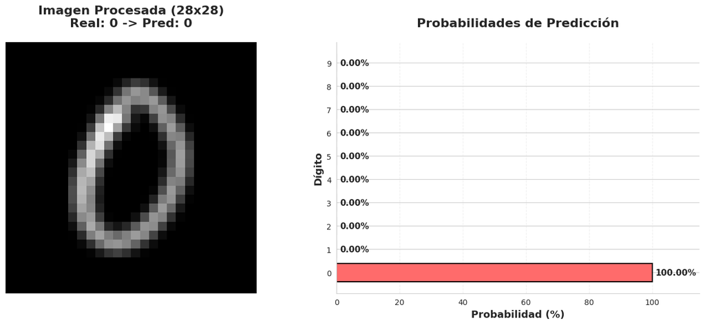

```
Procesando: digito1.png (real=1)
```

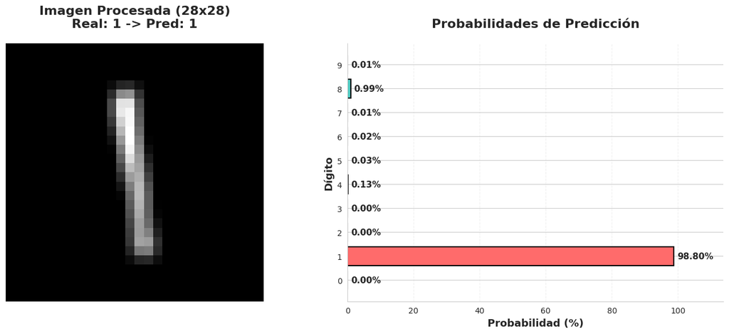

```
Procesando: digito2.png (real=2)
```

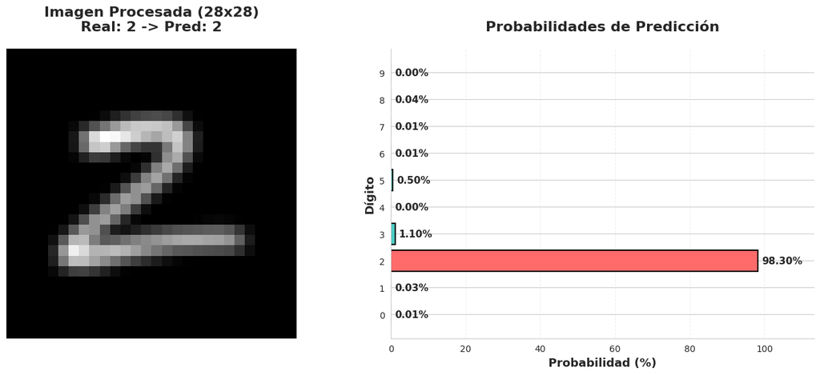

```
Procesando: digito3.png (real=3)
```

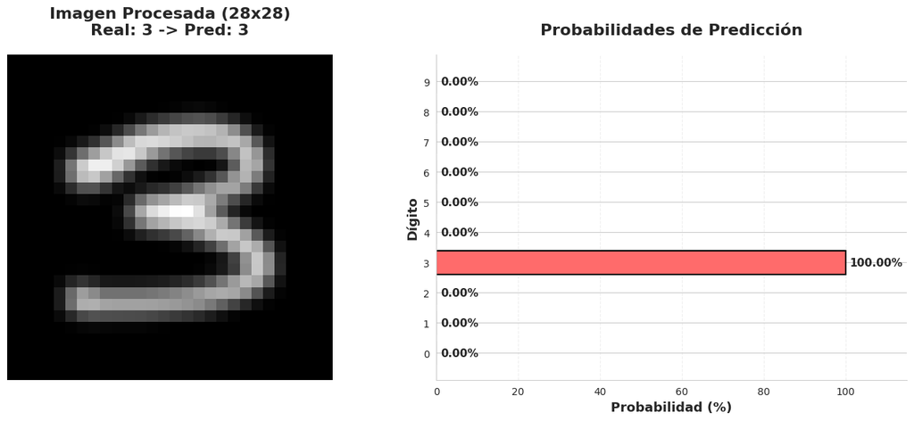

```
Procesando: digito4.png (real=4)
```

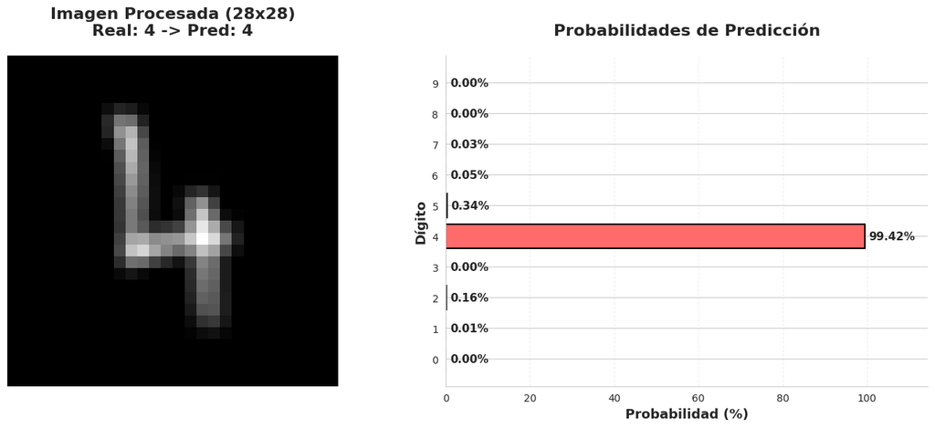

```
Procesando: digito5.png (real=5)
```

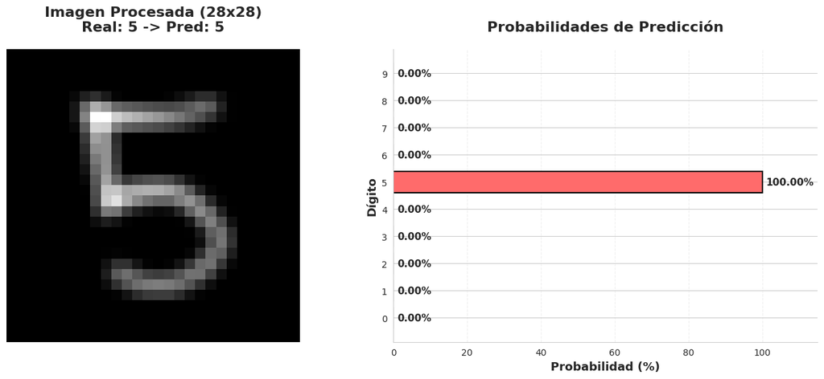

```
Procesando: digito6.png (real=6)
```

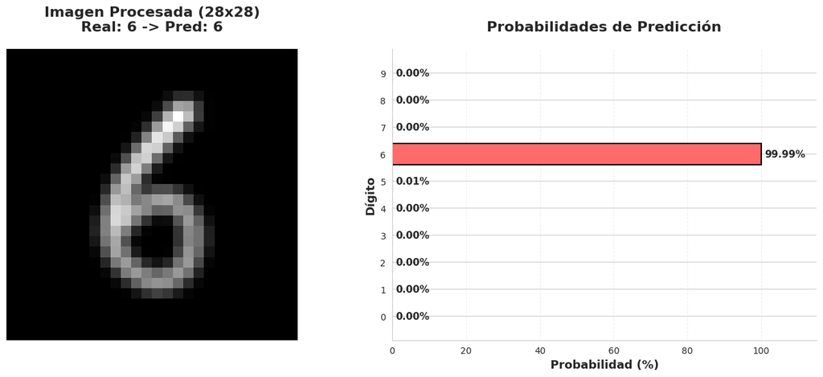

```
Procesando: digito7.png (real=7)
```

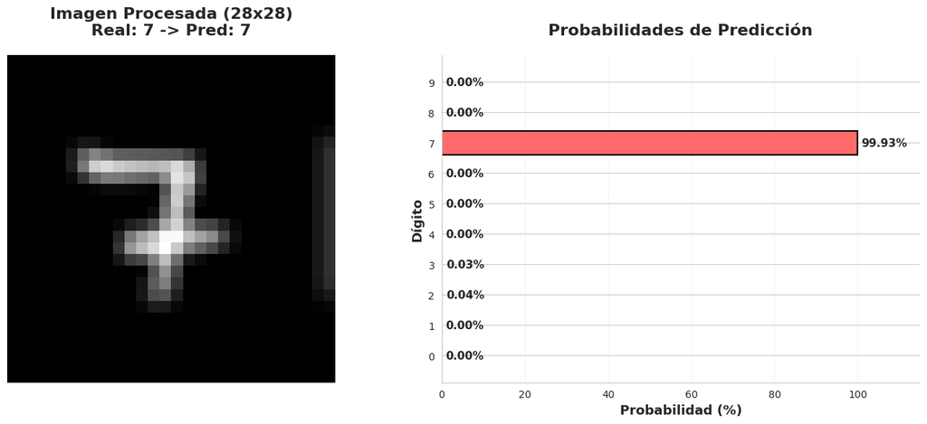

```
Procesando: digito8.png (real=8)
```

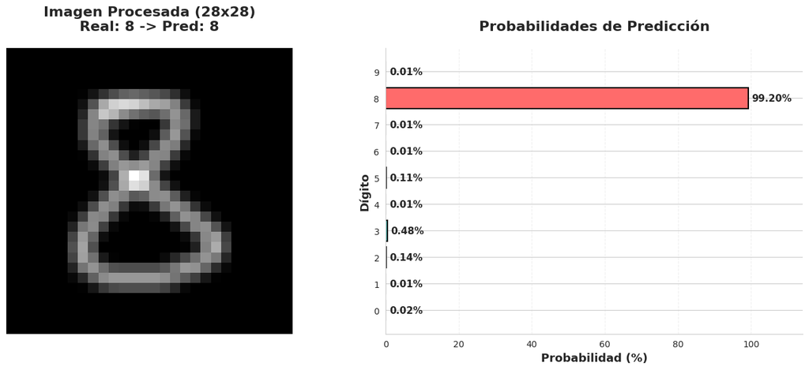

```
Procesando: digito9.png (real=9)
```

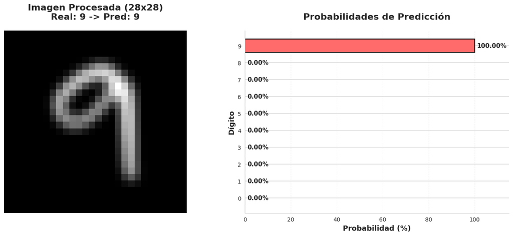

```
============================================================
RESULTADOS CON MODELO KERAS (10 dígitos)
============================================================
✓ Correcto: digito0.png -> real=0, pred=0, conf=100.00%
✓ Correcto: digito1.png -> real=1, pred=1, conf=98.80%
✓ Correcto: digito2.png -> real=2, pred=2, conf=98.30%
✓ Correcto: digito3.png -> real=3, pred=3, conf=100.00%
✓ Correcto: digito4.png -> real=4, pred=4, conf=99.42%
✓ Correcto: digito5.png -> real=5, pred=5, conf=100.00%
✓ Correcto: digito6.png -> real=6, pred=6, conf=99.99%
✓ Correcto: digito7.png -> real=7, pred=7, conf=99.93%
✓ Correcto: digito8.png -> real=8, pred=8, conf=99.20%
✓ Correcto: digito9.png -> real=9, pred=9, conf=100.00%

Tasa de acierto: 10/10 = 100.0%

Resultados guardados en: /home/fernando/Desktop/Máster_IAI/Aprendizaje_Profundo/PECs/PEC0/PEC_0_Entrega/resultados_keras
============================================================
```

```python
# ======================================================
# PREDICCIÓN CON EL MEJOR MODELO OBTENIDO MANUALMENTE
# ======================================================

from PIL import Image, ImageOps

# ==============================
# CONFIGURACIÓN
# ==============================
sns.set_style("whitegrid")
plt.rcParams['figure.figsize'] = (14, 6)

MODEL_PATH = "best_model_tuner.keras"
IMAGE_NAMES = [f"digito{i}.png" for i in range(10)]
SAVE_DIR = "./resultados_keras"
os.makedirs(SAVE_DIR, exist_ok=True)

# ==============================
# FUNCIÓN: Preprocesar imagen
# ==============================
def preprocess_image(image_path, output_path=None):
    """
    Optimiza la imagen para predicción MNIST.
    MNIST espera: 28x28, escala de grises, fondo negro, dígito blanco, normalizado [0,1]
    """
    img = Image.open(image_path).convert('L')
    img_array = np.array(img)

    # Invertir si fondo es blanco
    if np.mean(img_array) > 127:
        img = ImageOps.invert(img)
        img_array = np.array(img)

    # Umbralización con Otsu
    _, img_array = cv2.threshold(img_array, 0, 255, cv2.THRESH_BINARY + cv2.THRESH_OTSU)

    # Recortar bounding box
    coords = cv2.findNonZero(img_array)
    if coords is not None:
        x, y, w, h = cv2.boundingRect(coords)
        padding = int(max(w, h) * 0.3) # Se cambia de 0.2 a 0.3 para mejorar la precisión de la predicción del dígito_9, aumenta a 100%
        x = max(0, x - padding)
        y = max(0, y - padding)
        w = min(img_array.shape[1] - x, w + 2 * padding)
        h = min(img_array.shape[0] - y, h + 2 * padding)
        img_cropped = img_array[y:y+h, x:x+w]
    else:
        img_cropped = img_array

    # Hacer cuadrada y centrar
    max_dim = max(img_cropped.shape)
    square_img = np.zeros((max_dim, max_dim), dtype=np.uint8)
    y_off = (max_dim - img_cropped.shape[0]) // 2
    x_off = (max_dim - img_cropped.shape[1]) // 2
    square_img[y_off:y_off+img_cropped.shape[0], x_off:x_off+img_cropped.shape[1]] = img_cropped

    # Redimensionar a 28x28
    img_resized = cv2.resize(square_img, (28, 28), interpolation=cv2.INTER_AREA)
    img_resized = cv2.GaussianBlur(img_resized, (3, 3), 0)

    # Guardar si se especifica
    if output_path:
        Image.fromarray(img_resized).save(output_path)

    # Normalizar a [0,1]
    img_normalized = img_resized.astype(np.float32) / 255.0
    return img_normalized, img_resized

# ==============================
# FUNCIÓN: Cargar modelo Keras
# ==============================
def load_keras_model(model_path):
    """
    Carga el modelo Keras desde el archivo .keras
    """
    try:
        model = keras.models.load_model(model_path)
        print(f"Modelo cargado exitosamente desde: {model_path}")
        print(f"Arquitectura del modelo:")
        model.summary()
        return model
    except Exception as e:
        print(f"Error al cargar el modelo: {e}")
        raise

# ==============================
# FUNCIÓN: Predicción con Keras
# ==============================
def predict_digit_keras(model, img_normalized):
    """
    Realiza la predicción usando el modelo Keras cargado.
    """
    # Determinar la forma de entrada del modelo
    input_shape = model.input_shape

    # Adaptar la imagen según la forma esperada
    if len(input_shape) == 4:  # (batch, height, width, channels)
        if input_shape[-1] == 1:  # (None, 28, 28, 1)
            img_input = np.expand_dims(img_normalized, axis=(0, -1))
        else:  # Formato no estándar
            img_input = np.expand_dims(img_normalized, axis=0)
    elif len(input_shape) == 3:  # (batch, height, width)
        img_input = np.expand_dims(img_normalized, axis=0)
    elif len(input_shape) == 2:  # (batch, features)
        img_input = img_normalized.flatten().reshape(1, -1)
    else:
        # Por defecto, asumir (batch, 28, 28, 1)
        img_input = np.expand_dims(img_normalized, axis=(0, -1))

    # Asegurar tipo float32
    img_input = img_input.astype(np.float32)

    # Inferencia
    predictions = model.predict(img_input, verbose=0)[0]

    return predictions

# ==============================
# FUNCIÓN: Visualización
# ==============================
def visualize_results(predictions, img_display, real_digit, save_path=None):
    fig, (ax1, ax2) = plt.subplots(1, 2, figsize=(14, 6))

    pred_digit = np.argmax(predictions)
    conf = np.max(predictions) * 100

    ax1.imshow(img_display, cmap='gray')
    ax1.set_title(f'Imagen Procesada (28x28)\nReal: {real_digit} -> Pred: {pred_digit}',
                  fontsize=16, fontweight='bold', pad=20)
    ax1.axis('off')

    digits = np.arange(10)
    probabilities = predictions * 100
    colors = ['#FF6B6B' if i == pred_digit else '#4ECDC4' for i in range(10)]

    bars = ax2.barh(digits, probabilities, color=colors, edgecolor='black', linewidth=1.5)
    for i, (bar, prob) in enumerate(zip(bars, probabilities)):
        width = bar.get_width()
        label = f'{prob:.2f}%'
        ax2.text(width + 1, bar.get_y() + bar.get_height()/2, label,
                 ha='left', va='center', fontsize=11, fontweight='bold')

    ax2.set_xlabel('Probabilidad (%)', fontsize=13, fontweight='bold')
    ax2.set_ylabel('Dígito', fontsize=13, fontweight='bold')
    ax2.set_title('Probabilidades de Predicción', fontsize=16, fontweight='bold', pad=20)
    ax2.set_xlim(0, max(probabilities) + 15)
    ax2.set_yticks(digits)
    ax2.grid(axis='x', alpha=0.3, linestyle='--')
    ax2.spines['top'].set_visible(False)
    ax2.spines['right'].set_visible(False)

    plt.tight_layout()
    if save_path:
        plt.savefig(save_path, dpi=300, bbox_inches='tight')
    plt.show()

# ==============================
# EJECUCIÓN PRINCIPAL
# ==============================
print("="*60)
print("SISTEMA DE PREDICCIÓN DE DÍGITOS CON KERAS")
print("="*60)

# Cargar el modelo Keras
model = load_keras_model(MODEL_PATH)

resultados = []

for nombre_img in IMAGE_NAMES:
    ruta = nombre_img
    if not os.path.exists(ruta):
        print(f"Advertencia: {nombre_img} no encontrado. Saltando.")
        continue

    real_digit = int(nombre_img.replace("digito", "").replace(".png", ""))
    print(f"\nProcesando: {nombre_img} (real={real_digit})")

    try:
        img_norm, img_disp = preprocess_image(
            ruta,
            output_path=os.path.join(SAVE_DIR, f"procesado_{nombre_img}")
        )
        preds = predict_digit_keras(model, img_norm)
        pred_digit = int(np.argmax(preds))
        conf = float(np.max(preds))

        resultados.append({
            'archivo': nombre_img,
            'real': real_digit,
            'pred': pred_digit,
            'conf': conf,
            'probs': preds
        })

        # Visualizar y guardar
        save_plot = os.path.join(SAVE_DIR, f"resultado_{nombre_img.replace('.png', '.png')}")
        visualize_results(preds, img_disp, real_digit, save_path=save_plot)

    except Exception as e:
        print(f"Error con {nombre_img}: {e}")
        import traceback
        traceback.print_exc()
        continue

# ==============================
# RESUMEN FINAL
# ==============================
print("\n" + "="*60)
print("RESULTADOS CON MODELO KERAS (10 dígitos)")
print("="*60)

aciertos = 0
for r in resultados:
    estado = "✓ Correcto" if r['real'] == r['pred'] else "✗ Incorrecto"
    print(f"{estado}: {r['archivo']} -> real={r['real']}, pred={r['pred']}, conf={r['conf']*100:.2f}%")
    if r['real'] == r['pred']:
        aciertos += 1

total = len(resultados)
if total > 0:
    print(f"\nTasa de acierto: {aciertos}/{total} = {aciertos/total:.1%}")
print(f"\nResultados guardados en: {os.path.abspath(SAVE_DIR)}")
print("="*60)
```

# Execution Results

## 1. Manual Hyperparameter Optimization

The first phase of the experiment consisted of manual optimization of eight combinations of architectures and learning rates. The code trains each model and records the final metrics. Below is the comparative table generated by the script execution.

### 1.1. Comparative Table of Models

[output not shown]

## 2. Búsqueda Automática con Keras Tuner

La búsqueda automática con Keras Tuner validó los hallazgos manuales. El tuner exploró 20 combinaciones diferentes de arquitecturas y tasas de aprendizaje. A continuación se muestran los resultados obtenidos directamente de la consola.

### 2.1. Tuner Search Summary

[output not shown]

## 3. Visualization with TensorBoard

### 3.1. Manual Optimization Graphs

[figure not shown]

**Figure 1:** Graph of validation and train accuracy (`epoch_accuracy`).

[figure not shown]

**Figure 2:** Graph of validation and train loss (`epoch_loss`). Model `3H_A_LR_A` shows the lowest and most stable loss.

### 3.2. Keras Tuner Graphs

[figure not shown]

**Figure 3:** Graph of validation and train accuracy (`epoch_accuracy`) Keras Tuner Trial ID:19.

[figure not shown]

**Figure 4:** Graph of validation and train loss (`epoch_loss`) Keras Tuner Trial ID:19.